# ISLR Chapter 6 Exercises

Ryan Heslin

11/16/2020

# Conceptual

##1. We perform best subset, forward stepwise, and backward stepwise selection on a single data set. For each approach, we obtainp+1models, containing 0,1,2,…,ppredictors. Explain your answers:(a) Which of the three models with kpredictors has the smallesttrainingRSS?(b) Which of the three models withkpredictors has the smallesttestRSS?(c) True or False:i. The predictors in thek-variable model identified by forwardstepwise are a subset of the predictors in the (k+1)-variablemodel identified by forward stepwise selection.ii. The predictors in thek-variable model identified by back-ward stepwise are a subset of the predictors in the (k+1)-variable model identified by backward stepwise selection.iii. The predictors in thek-variable model identified by back-ward stepwise are a subset of the predictors in the (k+1)-variable model identified by forward stepwise selection.iv. The predictors in thek-variable model identified by forwardstepwise are a subset of the predictors in the (k+1)-variablemodel identified by backward stepwise selection.v. The predictors in thek-variable model identified by bestsubset are a subset of the predictors in the (k+1)-variablemodel identified by best subset selection

1. The best subset selection. Because it tries every model combination, it is guaranteed to find the one with the lowest training RSS (thought he others may as well).
2. It depends on the number of predictors. If it is high, then the best subset approach, because it is exhaustive, is more likely to find a combination that overfits the training data. With fewer predictors, this is unlikely.
3. True. Each $M_{k+1}$ adds another predicotr without removing any
2. True, for the same reasons.
3. Not necessarily. Each approach adds/subtracts preds for their RSS improvement relative to the previous iteration, not RSS in a simple regression, which means their paths don’t necessairyl converge
4. False, for the same reasons
5. True, because best subset only ever adds preds.

##2. For parts (a) through (c), indicate which of i. through iv. is correct.Justify your answer.(a) The lasso, relative to least squares, is:i. More flexible and hence will give improved prediction ac-curacy when its increase in bias is less than its decrease in variance.ii. More flexible and hence will give improved prediction accu-racy when its increase in variance is less than its decreasein bias. 2606. Linear Model Selection and Regularization iii. Less flexible and hence will give improved prediction accu-racy when its increase in bias is less than its decrease invariance.iv. Less flexible and hence will give improved prediction accu-racy when its increase in variance is less than its decreasein bias.(b) Repeat (a) for ridge regression relative to least squares.(c) Repeat (a) for non-linear methods relative to least squares.

Lasso

a i. False; it is less flexible because it removes parameters, though the second part of the statement is generally true.

2. False. The lasso reduces variance relative to OLS because it adds a constraint.
3. True, for reasons stated above.
4. False.

The same sets of statements are correct, though RR does not reduce variacne as much as the lasso becuase it never removes predictors.

Nonlinear Methods

1. False. Nonlinear methods are more flexible and therefore reduce bias at the expense of variance.
2. True.
3. False.
4. False.

This problem looks at the lasso, which constrains the sume of the absolute value of the betas.

My initial answers here were wrong; corrections are appended.

1. As we increases from 0, the training RSS will: i. Increase initially, and then eventually start decreasing in an inverted U shape.ii. Decrease initially, and then eventually start increasing in aUshape.iii. Steadily increase.iv. Steadily decrease.v. Remain constant.(b) Repeat (a) for test RSS.(c) Repeat (a) for variance.(d) Repeat (a) for (squared) bias.(e) Repeat (a) for the irreducible error.

_You have this backward-the higher $s$ is, the MORE freedom you have to estimate the betas

Lasso: a iv. Adding predictors always lowers training RSS, even if they are unreslted to the response. Conversely, removing them, as the lasso does, will increase RSS. *Once s becomes big enough, no predictors are zeroed, leading to the OLS solution.*

2. 2. The lasso is more biased than OLS, but the constraint greatly reduces variance. As a result, test RSS falls until reaching a minimum where the model becomes too balanced to be useful. *Actually iii-as s increases, $\lambda$ falls*.
3. 3. Removing predictors lowers variance, since it reduces the number of parameters the model must estimate.
4. 4. The cost of removing predictors is increasing bias - i.e., finding a simpler model than the true function. _Again wrong - bias falls with $s$, since it represents an increasing $\lambda$.
5. 4. This is essentially training RSS, so iv. *Wrong yet again - be definition, irreducible error cannot be explained by any model of the given predictors*.
4. We are then asked to repeat the problem for ridge regression, this time with $\lambda$ increasing instead of $s$.
1. Steadily increase. Increasing $\lambda$ reduces the effect of predictors, lowering training performance
2. Decrease initially, then start increasing. The bias-variance tradeoff improves test RSS until the minimum of the curve.
3. Steadily decrease. Lowering betas reduces variance.
4. Steadily increase, since reducing betas simpliefies the model
5. Remains constant, for the reasons given above.

# Lab: Subset Slection

59 salaries are NA, so we drop those rows.

```r
library(ISLR)
library(tidyverse)
library(rlang)
hitters <- Hitters

glimpse(hitters)
```

```
## Rows: 322
## Columns: 20
## $ AtBat     <int> 293, 315, 479, 496, 321, 594, 185, 298, 323, 401, 574, 20...
## $ Hits      <int> 66, 81, 130, 141, 87, 169, 37, 73, 81, 92, 159, 53, 113, ...
## $ HmRun     <int> 1, 7, 18, 20, 10, 4, 1, 0, 6, 17, 21, 4, 13, 0, 7, 3, 20,...
## $ Runs      <int> 30, 24, 66, 65, 39, 74, 23, 24, 26, 49, 107, 31, 48, 30, ...
## $ RBI       <int> 29, 38, 72, 78, 42, 51, 8, 24, 32, 66, 75, 26, 61, 11, 27...
## $ Walks     <int> 14, 39, 76, 37, 30, 35, 21, 7, 8, 65, 59, 27, 47, 22, 30,...
## $ Years     <int> 1, 14, 3, 11, 2, 11, 2, 3, 2, 13, 10, 9, 4, 6, 13, 3, 15,...
## $ CAtBat    <int> 293, 3449, 1624, 5628, 396, 4408, 214, 509, 341, 5206, 46...
## $ CHits     <int> 66, 835, 457, 1575, 101, 1133, 42, 108, 86, 1332, 1300, 4...
## $ CHmRun    <int> 1, 69, 63, 225, 12, 19, 1, 0, 6, 253, 90, 15, 41, 4, 36, ...
## $ CRuns     <int> 30, 321, 224, 828, 48, 501, 30, 41, 32, 784, 702, 192, 20...
## $ CRBI      <int> 29, 414, 266, 838, 46, 336, 9, 37, 34, 890, 504, 186, 204...
## $ CWalks    <int> 14, 375, 263, 354, 33, 194, 24, 12, 8, 866, 488, 161, 203...
## $ League    <fct> A, N, A, N, N, A, N, A, N, A, A, N, N, A, N, A, N, A, A, ...
## $ Division  <fct> E, W, W, E, E, W, E, W, W, E, E, W, E, E, E, W, W, W, W, ...
## $ PutOuts   <int> 446, 632, 880, 200, 805, 282, 76, 121, 143, 0, 238, 304, ...
## $ Assists   <int> 33, 43, 82, 11, 40, 421, 127, 283, 290, 0, 445, 45, 11, 1...
## $ Errors    <int> 20, 10, 14, 3, 4, 25, 7, 9, 19, 0, 22, 11, 7, 6, 8, 0, 10...
## $ Salary    <dbl> NA, 475.000, 480.000, 500.000, 91.500, 750.000, 70.000, 1...
## $ NewLeague <fct> A, N, A, N, N, A, A, A, N, A, A, N, N, A, N, A, N, A, A, ...
```

```r
map(hitters, ~sum(is.na(.x)))
```

```
## $AtBat
## [1] 0
##
## $Hits
## [1] 0
##
## $HmRun
## [1] 0
##
## $Runs
## [1] 0
##
## $RBI
## [1] 0
##
## $Walks
## [1] 0
##
## $Years
## [1] 0
##
## $CAtBat
## [1] 0
##
## $CHits
## [1] 0
##
## $CHmRun
## [1] 0
##
## $CRuns
## [1] 0
##
## $CRBI
## [1] 0
##
## $CWalks
## [1] 0
##
## $League
## [1] 0
##
## $Division
## [1] 0
##
## $PutOuts
## [1] 0
##
## $Assists
## [1] 0
##
## $Errors
## [1] 0
##
## $Salary
## [1] 59
##
## $NewLeague
## [1] 0
```

```r
hitters <- hitters[complete.cases(hitters),]
```

```r
library(leaps)

full <- regsubsets(Salary ~., hitters)
summary(full)
```

```
## Subset selection object
## Call: regsubsets.formula(Salary ~ ., hitters)
## 19 Variables  (and intercept)
##            Forced in Forced out
## AtBat          FALSE      FALSE
## Hits           FALSE      FALSE
## HmRun          FALSE      FALSE
## Runs           FALSE      FALSE
## RBI            FALSE      FALSE
## Walks          FALSE      FALSE
## Years          FALSE      FALSE
## CAtBat         FALSE      FALSE
## CHits          FALSE      FALSE
## CHmRun         FALSE      FALSE
## CRuns          FALSE      FALSE
## CRBI           FALSE      FALSE
## CWalks         FALSE      FALSE
## LeagueN        FALSE      FALSE
## DivisionW      FALSE      FALSE
## PutOuts        FALSE      FALSE
## Assists        FALSE      FALSE
## Errors         FALSE      FALSE
## NewLeagueN     FALSE      FALSE
## 1 subsets of each size up to 8
## Selection Algorithm: exhaustive
##          AtBat Hits HmRun Runs RBI Walks Years CAtBat CHits CHmRun CRuns CRBI
## 1  ( 1 ) " "   " "  " "   " "  " " " "   " "   " "    " "   " "    " "   "*"
## 2  ( 1 ) " "   "*"  " "   " "  " " " "   " "   " "    " "   " "    " "   "*"
## 3  ( 1 ) " "   "*"  " "   " "  " " " "   " "   " "    " "   " "    " "   "*"
## 4  ( 1 ) " "   "*"  " "   " "  " " " "   " "   " "    " "   " "    " "   "*"
## 5  ( 1 ) "*"   "*"  " "   " "  " " " "   " "   " "    " "   " "    " "   "*"
## 6  ( 1 ) "*"   "*"  " "   " "  " " "*"   " "   " "    " "   " "    " "   "*"
## 7  ( 1 ) " "   "*"  " "   " "  " " "*"   " "   "*"    "*"   "*"    " "   " "
## 8  ( 1 ) "*"   "*"  " "   " "  " " "*"   " "   " "    " "   "*"    "*"   " "
##          CWalks LeagueN DivisionW PutOuts Assists Errors NewLeagueN
## 1  ( 1 ) " "    " "     " "       " "     " "     " "    " "
## 2  ( 1 ) " "    " "     " "       " "     " "     " "    " "
## 3  ( 1 ) " "    " "     " "       "*"     " "     " "    " "
## 4  ( 1 ) " "    " "     "*"       "*"     " "     " "    " "
## 5  ( 1 ) " "    " "     "*"       "*"     " "     " "    " "
## 6  ( 1 ) " "    " "     "*"       "*"     " "     " "    " "
## 7  ( 1 ) " "    " "     "*"       "*"     " "     " "    " "
## 8  ( 1 ) "*"    " "     "*"       "*"     " "     " "    " "
```

```r
max_pred <- regsubsets(Salary~., hitters, nvmax = 19)

#Order of addition
summary(max_pred)$which %>% {.[, rev(order(colSums(.)))]} %>% colnames()
```

```
##  [1] "(Intercept)" "Hits"        "PutOuts"     "CRBI"        "DivisionW"
##  [6] "Walks"       "AtBat"       "CWalks"      "CRuns"       "CAtBat"
## [11] "Assists"     "LeagueN"     "Runs"        "Errors"      "CHits"
## [16] "HmRun"       "RBI"         "NewLeagueN"  "CHmRun"      "Years"
```

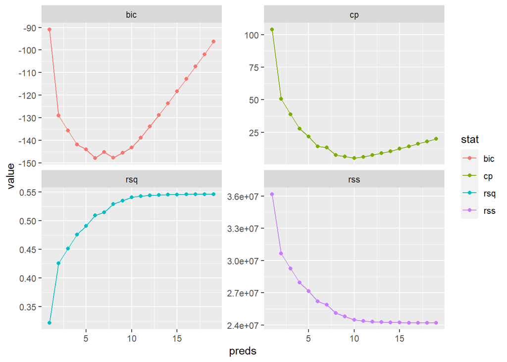

```r
summary(max_pred) %>% {tibble(preds = 1:19, bic = .$bic, cp = .$cp, rss = .$rss, rsq = .$rsq )} %>%
  pivot_longer(cols = bic:last_col(), names_to = "stat") %>%
  ggplot(aes(x = preds, y = value, col = stat)) +
  geom_point() +
  geom_line() +
  facet_wrap(.~ stat, scales = "free_y")
```

Obviously the last model has the best RSS, the first the worst R squared. The tenth minimizes $C_p$.

Black plot rectangles represent variables picked in the model that generated that statistic.

```r
summary(max_pred) %>% {tibble(preds = 1:19, bic = .$bic, cp = .$cp, rss = .$rss, rsq = .$rsq )} %>%
  map(which.min)
```

```
## $preds
## [1] 1
##
## $bic
## [1] 6
##
## $cp
## [1] 10
##
## $rss
## [1] 19
##
## $rsq
## [1] 1
```

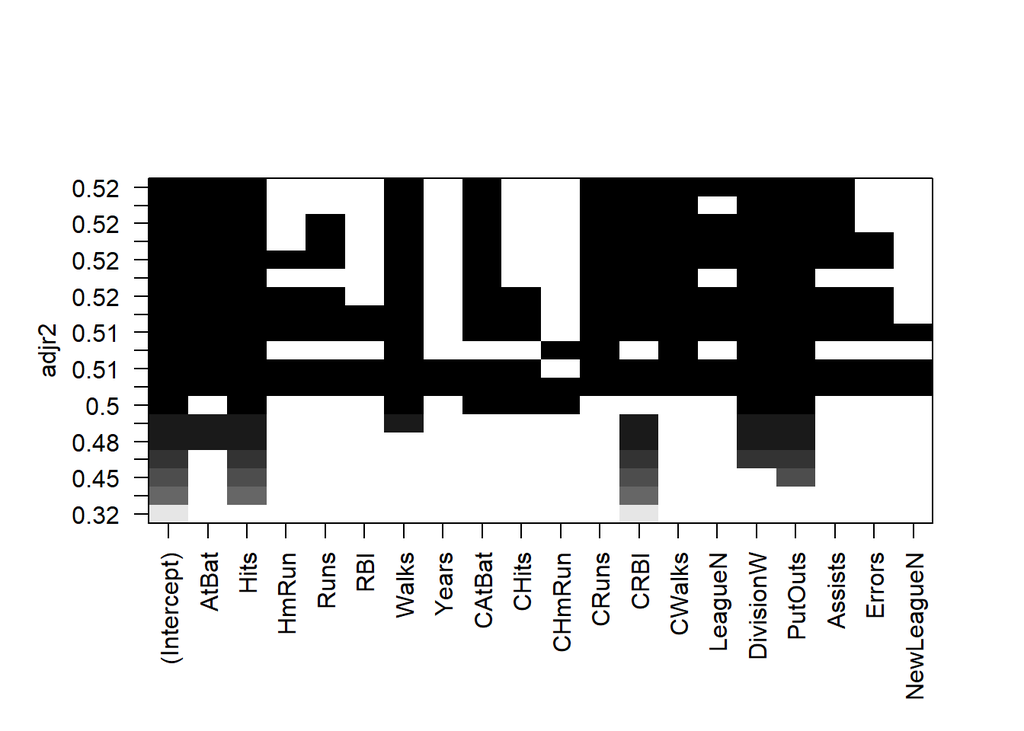

```r
plot(max_pred, scale = "adjr2")
```

Forward selection. The three models start to diverge at the seventh predictor.

```r
fwd <- regsubsets(Salary ~., hitters, nvmax = 19, method = "forward")
summary(fwd)
```

```
## Subset selection object
## Call: regsubsets.formula(Salary ~ ., hitters, nvmax = 19, method = "forward")
## 19 Variables  (and intercept)
##            Forced in Forced out
## AtBat          FALSE      FALSE
## Hits           FALSE      FALSE
## HmRun          FALSE      FALSE
## Runs           FALSE      FALSE
## RBI            FALSE      FALSE
## Walks          FALSE      FALSE
## Years          FALSE      FALSE
## CAtBat         FALSE      FALSE
## CHits          FALSE      FALSE
## CHmRun         FALSE      FALSE
## CRuns          FALSE      FALSE
## CRBI           FALSE      FALSE
## CWalks         FALSE      FALSE
## LeagueN        FALSE      FALSE
## DivisionW      FALSE      FALSE
## PutOuts        FALSE      FALSE
## Assists        FALSE      FALSE
## Errors         FALSE      FALSE
## NewLeagueN     FALSE      FALSE
## 1 subsets of each size up to 19
## Selection Algorithm: forward
##           AtBat Hits HmRun Runs RBI Walks Years CAtBat CHits CHmRun CRuns CRBI
## 1  ( 1 )  " "   " "  " "   " "  " " " "   " "   " "    " "   " "    " "   "*"
## 2  ( 1 )  " "   "*"  " "   " "  " " " "   " "   " "    " "   " "    " "   "*"
## 3  ( 1 )  " "   "*"  " "   " "  " " " "   " "   " "    " "   " "    " "   "*"
## 4  ( 1 )  " "   "*"  " "   " "  " " " "   " "   " "    " "   " "    " "   "*"
## 5  ( 1 )  "*"   "*"  " "   " "  " " " "   " "   " "    " "   " "    " "   "*"
## 6  ( 1 )  "*"   "*"  " "   " "  " " "*"   " "   " "    " "   " "    " "   "*"
## 7  ( 1 )  "*"   "*"  " "   " "  " " "*"   " "   " "    " "   " "    " "   "*"
## 8  ( 1 )  "*"   "*"  " "   " "  " " "*"   " "   " "    " "   " "    "*"   "*"
## 9  ( 1 )  "*"   "*"  " "   " "  " " "*"   " "   "*"    " "   " "    "*"   "*"
## 10  ( 1 ) "*"   "*"  " "   " "  " " "*"   " "   "*"    " "   " "    "*"   "*"
## 11  ( 1 ) "*"   "*"  " "   " "  " " "*"   " "   "*"    " "   " "    "*"   "*"
## 12  ( 1 ) "*"   "*"  " "   "*"  " " "*"   " "   "*"    " "   " "    "*"   "*"
## 13  ( 1 ) "*"   "*"  " "   "*"  " " "*"   " "   "*"    " "   " "    "*"   "*"
## 14  ( 1 ) "*"   "*"  "*"   "*"  " " "*"   " "   "*"    " "   " "    "*"   "*"
```

[output cut: 10 more lines]

```
## 5  ( 1 )  " "    " "     "*"       "*"     " "     " "    " "
## 6  ( 1 )  " "    " "     "*"       "*"     " "     " "    " "
## 7  ( 1 )  "*"    " "     "*"       "*"     " "     " "    " "
## 8  ( 1 )  "*"    " "     "*"       "*"     " "     " "    " "
## 9  ( 1 )  "*"    " "     "*"       "*"     " "     " "    " "
## 10  ( 1 ) "*"    " "     "*"       "*"     "*"     " "    " "
## 11  ( 1 ) "*"    "*"     "*"       "*"     "*"     " "    " "
## 12  ( 1 ) "*"    "*"     "*"       "*"     "*"     " "    " "
## 13  ( 1 ) "*"    "*"     "*"       "*"     "*"     "*"    " "
## 14  ( 1 ) "*"    "*"     "*"       "*"     "*"     "*"    " "
## 15  ( 1 ) "*"    "*"     "*"       "*"     "*"     "*"    " "
## 16  ( 1 ) "*"    "*"     "*"       "*"     "*"     "*"    " "
## 17  ( 1 ) "*"    "*"     "*"       "*"     "*"     "*"    "*"
## 18  ( 1 ) "*"    "*"     "*"       "*"     "*"     "*"    "*"
## 19  ( 1 ) "*"    "*"     "*"       "*"     "*"     "*"    "*"
```

```r
backwd <- regsubsets(Salary ~., hitters, nvmax = 19, method = "backward")

map(list(max_pred, fwd, backwd), coef, 7)
```

```
## [[1]]
##  (Intercept)         Hits        Walks       CAtBat        CHits       CHmRun
##   79.4509472    1.2833513    3.2274264   -0.3752350    1.4957073    1.4420538
##    DivisionW      PutOuts
## -129.9866432    0.2366813
##
## [[2]]
##  (Intercept)        AtBat         Hits        Walks         CRBI       CWalks
##  109.7873062   -1.9588851    7.4498772    4.9131401    0.8537622   -0.3053070
##    DivisionW      PutOuts
## -127.1223928    0.2533404
##
## [[3]]
##  (Intercept)        AtBat         Hits        Walks        CRuns       CWalks
##  105.6487488   -1.9762838    6.7574914    6.0558691    1.1293095   -0.7163346
##    DivisionW      PutOuts
## -116.1692169    0.3028847
```

## Lab: Ridge regression and the Lasso

We need an explicit model matrix to proceed. The model matrix automatically creates dummies. Then we specify a tuning grid for $/lambda$. I compute the l2 norms of each beta vector. They vary inversely with $\lambda$.

```r
library(glmnet)
x <- model.matrix(Salary ~., Hitters)[,-1]
y <- hitters$Salary

grid <- 10^seq(10,-2,length=100)
ridge_mod <- glmnet(x, y, alpha = 0, lambda = grid)
summary(ridge_mod)
```

```
##           Length Class     Mode
## a0         100   -none-    numeric
## beta      1900   dgCMatrix S4
## df         100   -none-    numeric
## dim          2   -none-    numeric
## lambda     100   -none-    numeric
## dev.ratio  100   -none-    numeric
## nulldev      1   -none-    numeric
## npasses      1   -none-    numeric
## jerr         1   -none-    numeric
## offset       1   -none-    logical
## call         5   -none-    call
## nobs         1   -none-    numeric
```

```r
map_dbl(as.data.frame(as.matrix(coef(ridge_mod)))[-1,], ~sqrt(sum(.x^2))) %>%
  set_names(grid)
```

```
##              1e+10   7564633275.54629   5722367659.35022   4328761281.08306
##       8.080244e-06       1.068161e-05       1.412045e-05       1.866641e-05
##   3274549162.87773   2477076355.99171   1873817422.86039   1417474162.92681
##       2.467589e-05       3.262007e-05       4.312181e-05       5.700448e-05
##   1072267222.01033   811130830.789689   613590727.341316   464158883.361277
##       7.535654e-05       9.961687e-05       1.316876e-04       1.740831e-04
##   351119173.421513   265608778.294668   200923300.256505   151991108.295293
##       2.301274e-04       3.042145e-04       4.021530e-04       5.316214e-04
##   114975699.539774   86974900.2617783   65793322.4657568   49770235.6433211
##       7.027701e-04       9.290172e-04       1.228100e-03       1.623465e-03
##   37649358.0679247    28480358.684358   21544346.9003188   16297508.3462064
##       2.146106e-03       2.836993e-03       3.750279e-03       4.957547e-03
##   12328467.3944207    9326033.4688322   7054802.31071865    5336699.2312063
##       6.553409e-03       8.662911e-03       1.145132e-02       1.513702e-02
##   4037017.25859655   3053855.50883341   2310129.70008316   1747528.40000768
##       2.000861e-02       2.644732e-02       3.495677e-02       4.620200e-02
##   1321941.14846603              1e+06   756463.327554629   572236.765935022
##       6.106098e-02       8.069225e-02       1.066237e-01       1.408688e-01
##   432876.128108306   327454.916287772   247707.635599171   187381.742286038
##       1.860785e-01       2.457380e-01       3.244221e-01       4.280258e-01
##    141747.41629268   107226.722201032   81113.0830789687   61359.0727341318
##       5.644992e-01       7.439495e-01       9.795347e-01       1.288190e+00
##   46415.8883361277   35111.9173421513   26560.8778294668   20092.3300256505
##       1.691554e+00       2.217044e+00       2.899049e+00       3.780239e+00
##   15199.1108295293   11497.5699539774   8697.49002617783   6579.33224657568
##       4.912948e+00       6.360612e+00       8.199134e+00       1.051786e+01
##   4977.02356433211   3764.93580679246    2848.0358684358   2154.43469003188
##       1.341921e+01       1.701538e+01       2.141932e+01       2.672852e+01
##   1629.75083462064   1232.84673944207    932.60334688322   705.480231071865
##       3.300168e+01       4.023263e+01       4.833021e+01       5.711001e+01
##    533.66992312063   403.701725859655   305.385550883341   231.012970008316
##       6.630814e+01       7.561264e+01       8.470897e+01       9.332675e+01
##   174.752840000768   132.194114846603                100   75.6463327554629
##       1.012728e+02       1.084443e+02       1.148173e+02       1.204155e+02
##   57.2236765935022   43.2876128108306   32.7454916287773   24.7707635599171
##       1.252796e+02       1.294454e+02       1.329276e+02       1.357311e+02
##   18.7381742286039    14.174741629268   10.7226722201032   8.11130830789686
##       1.378778e+02       1.393982e+02       1.403536e+02       1.408310e+02
##   6.13590727341316   4.64158883361277   3.51119173421513   2.65608778294668
##       1.409308e+02       1.407486e+02       1.403885e+02       1.399206e+02
##   2.00923300256505   1.51991108295293   1.14975699539774  0.869749002617783
##       1.394321e+02       1.389295e+02       1.384658e+02       1.380379e+02
##  0.657933224657568  0.497702356433211  0.376493580679247   0.28480358684358
##       1.376681e+02       1.373535e+02       1.370975e+02       1.368910e+02
##  0.215443469003188  0.162975083462064  0.123284673944206 0.0932603346883218
##       1.367246e+02       1.365980e+02       1.364991e+02       1.364233e+02
## 0.0705480231071863  0.053366992312063 0.0403701725859655 0.0305385550883341
##       1.363668e+02       1.363198e+02       1.362867e+02       1.362580e+02
## 0.0231012970008316 0.0174752840000768 0.0132194114846603               0.01
##       1.362373e+02       1.362219e+02       1.362089e+02       1.362012e+02
```

Predict for new value of $\lambda$.

```r
predict(ridge_mod, s = 50, type = "coefficients")[1:20,]
```

```
##   (Intercept)         AtBat          Hits         HmRun          Runs
##  4.876610e+01 -3.580999e-01  1.969359e+00 -1.278248e+00  1.145892e+00
##           RBI         Walks         Years        CAtBat         CHits
##  8.038292e-01  2.716186e+00 -6.218319e+00  5.447837e-03  1.064895e-01
##        CHmRun         CRuns          CRBI        CWalks       LeagueN
##  6.244860e-01  2.214985e-01  2.186914e-01 -1.500245e-01  4.592589e+01
##     DivisionW       PutOuts       Assists        Errors    NewLeagueN
## -1.182011e+02  2.502322e-01  1.215665e-01 -3.278600e+00 -9.496680e+00
```

```r
set.seed(1)

inds <- sample(1:nrow(x), nrow(x)/2)

y_test <- y[-inds]

ridge_mod <- glmnet(x[inds,], y[inds], alpha = 0, lambda = grid, thresh = 1e-12)

mse <- mean((predict(ridge_mod, s = 4, newx = x[-inds,]) -y_test)^2)
```

Does this beat OLS? MSE is about $40000 higher.

```r
lin_mod <- lm(data = hitters[inds,], Salary ~ .)

 mean((predict(lin_mod, hitters[-inds,]) -hitters$Salary[-inds])^2)
```

```
## [1] 168593.3
```

We can use cv.glmnet to cross-validate $\lambda$. This gives a min of 408. Then predict the new model with the best lambda.

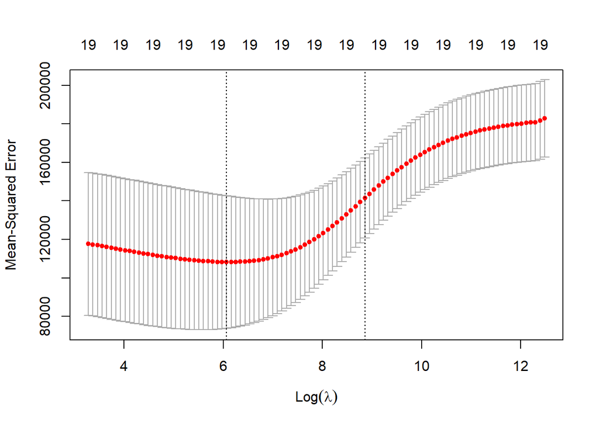

```r
cv <- cv.glmnet(x[inds,], y[inds], alpha = 0)
plot(cv)
```

```r
best <- 408
refined_mod <- glmnet(x, y, alpha =0)
predict(refined_mod, type = "coefficients", s =best)
```

```
## 20 x 1 sparse Matrix of class "dgCMatrix"
##                        1
## (Intercept)  22.59825210
## AtBat         0.09272966
## Hits          0.79398946
## HmRun         0.80958809
## Runs          1.03242916
## RBI           0.87710149
## Walks         1.53538983
## Years         1.83824564
## CAtBat        0.01130637
## CHits         0.05406927
## CHmRun        0.38530841
## CRuns         0.10800585
## CRBI          0.11386525
## CWalks        0.06139462
## LeagueN      19.55820627
## DivisionW   -72.00930045
## PutOuts       0.15234068
## Assists       0.02434440
## Errors       -1.14674679
## NewLeagueN    9.44851958
```

The lasso pretty much does the same thing, except alpha = 1.

## 3. PCR and PLS Regression

```r
library(pls)
mod_pcr <- pcr(Salary~., data = Hitters, subset = inds, scale = TRUE, validation = "CV")
summary(mod_pcr)
```

```
## Data:    X dimension: 99 19
##  Y dimension: 99 1
## Fit method: svdpc
## Number of components considered: 19
##
## VALIDATION: RMSEP
## Cross-validated using 10 random segments.
##        (Intercept)  1 comps  2 comps  3 comps  4 comps  5 comps  6 comps
## CV           451.8    354.5    346.6    350.2    353.2    337.9    340.7
## adjCV        451.8    353.2    345.3    348.9    351.4    335.8    338.7
##        7 comps  8 comps  9 comps  10 comps  11 comps  12 comps  13 comps
## CV       346.8    349.7    351.6     356.5     355.8     356.2     362.6
## adjCV    343.9    346.8    348.3     352.9     352.4     353.0     358.5
##        14 comps  15 comps  16 comps  17 comps  18 comps  19 comps
## CV        371.3     383.6     363.2     338.2     343.1     346.8
## adjCV     366.3     378.1     357.7     333.3     338.0     341.4
##
## TRAINING: % variance explained
##         1 comps  2 comps  3 comps  4 comps  5 comps  6 comps  7 comps  8 comps
## X         39.37    60.37    71.37    79.90    85.55    89.36    92.75    95.33
## Salary    43.55    47.87    48.44    50.01    54.95    55.58    56.47    56.52
##         9 comps  10 comps  11 comps  12 comps  13 comps  14 comps  15 comps
## X         96.62     97.48     98.26     98.83     99.25     99.58     99.78
## Salary    57.44     57.76     58.00     58.33     59.79     61.53     61.54
##         16 comps  17 comps  18 comps  19 comps
## X          99.91     99.97     99.99    100.00
## Salary     65.54     69.04     69.13     69.35
```

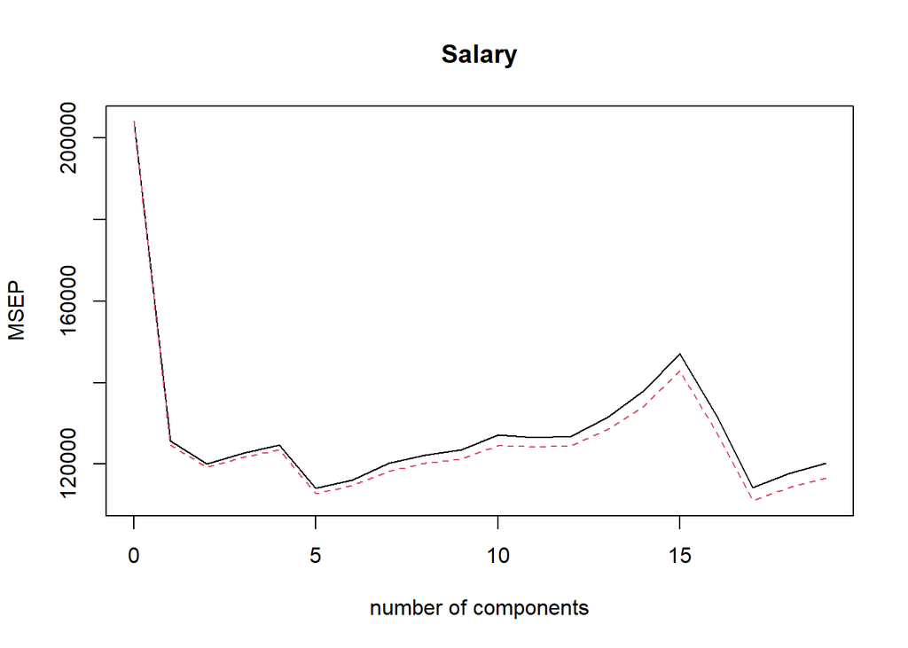

```r
validationplot(mod_pcr, val.type = "MSEP")
```

```r
preds <- predict(mod_pcr, x[inds,], ncomp =7)

mean((preds - y[inds])^2)
```

```
## [1] 108447.8
```

```r
pcr(Salary ~., data = Hitters, ncomp = 7, )
```

```
## Principal component regression , fitted with the singular value decomposition algorithm.
## Call:
## pcr(formula = Salary ~ ., ncomp = 7, data = Hitters)
```

I won’t bother doing PLSR, but the RMSE min is 2 components. It explains almost as much variance as the seven-component model because PLS explains variance in the response variable as well as the predictors.

## 8.

In this exercise, we will generate simulated data, and will then usethis data to perform best subset selection.(a) Use thernorm()function to generate a predictorXof lengthn= 100, as well as a noise vectorof lengthn= 100.(b) Generate a response vectorYof lengthn= 100 according tothe modelY=β0+β1X+β2X2+β3X3+,whereβ0,β1,β2,andβ3are constants of your choice.(c) Use theregsubsets()function to perform best subset selectionin order to choose the best model containing the predictorsX,X2,…,X10. What is the best model obtained according toCp,BIC,andadjustedR2? Show some plots to provide evidencefor your answer, and report the coefficients of the best model ob-tained. Note you will need to use thedata.frame()function tocreate a single data set containing bothXandY. 6.8 Exercises263(d) Repeat (c), using forward stepwise selection and also using back-wards stepwise selection. How does your answer compare to theresults in (c)?(e) Now fit a lasso model to the simulated data, again usingX,X2,…,X10as predictors. Use cross-validation to select the optimalvalue ofλ. Create plots of the cross-validation error as a functionofλ. Report the resulting coefficient estimates, and discuss theresults obtained.(f) Now generate a response vectorYaccording to the modelY=β0+β7X7+,and perform best subset selection and the lasso. Discuss theresults obtained.

Generate data. I choose some absurd betas to amuse myself.

```r
library(leaps)
set.seed(1)
x <- rnorm(n=100)
e <- rnorm(100)
y = 3 +7*x +.5*x^2  -3*x^3 + e

dat <- map_dfc(1:10, ~`^`(x, .x)) %>%
  set_names(paste0("x^", 1:10)) %>%
  mutate(y = y)
```

```
## * NA -> ...1
## * NA -> ...2
## * NA -> ...3
## * NA -> ...4
## * NA -> ...5
## * ...
```

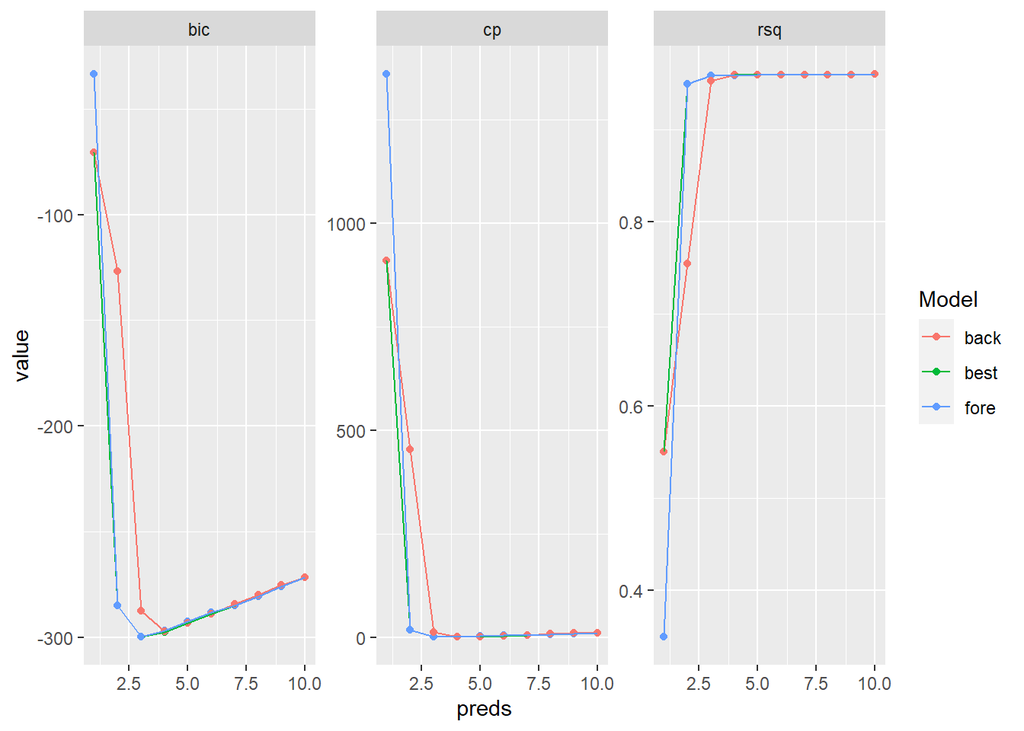

```r
best <- regsubsets(y~., dat, nvmax = 10)
back <- regsubsets(y~., dat, nvmax = 10, method ="backward")
fore <- regsubsets(y~., dat, nvmax = 10, method = "forward")

map(list(best, back, fore), summary) %>%
  map(~map2(list(.x), c("bic", "cp", "rsq"), ~pluck(.x, .y)) %>% set_names(c("bic", "cp", "rsq"))) %>%
  set_names(c("best", "fore", "back")) %>%
  map(bind_cols) %>%
  map(~mutate(.x, preds = 1:10)) %>%
  bind_rows(.id = "Model") %>%
  bind_cols() %>%
    pivot_longer(cols = c(bic, cp, rsq), names_to = "stat") %>%
  ggplot(aes(x = preds, y = value, col = Model))+
  geom_point()+
  geom_line()+
  facet_wrap(stat ~ ., scales = "free_y")
```

```r
coef(fore, 3)
```

```
## (Intercept)       `x^1`       `x^3`       `x^7`
##  3.34024763  7.36849738 -3.32811500  0.01331826
```

Now we fit a lasso model and cross-validate. I arbitrarily pick the same lambda values as the textbook in the lab.

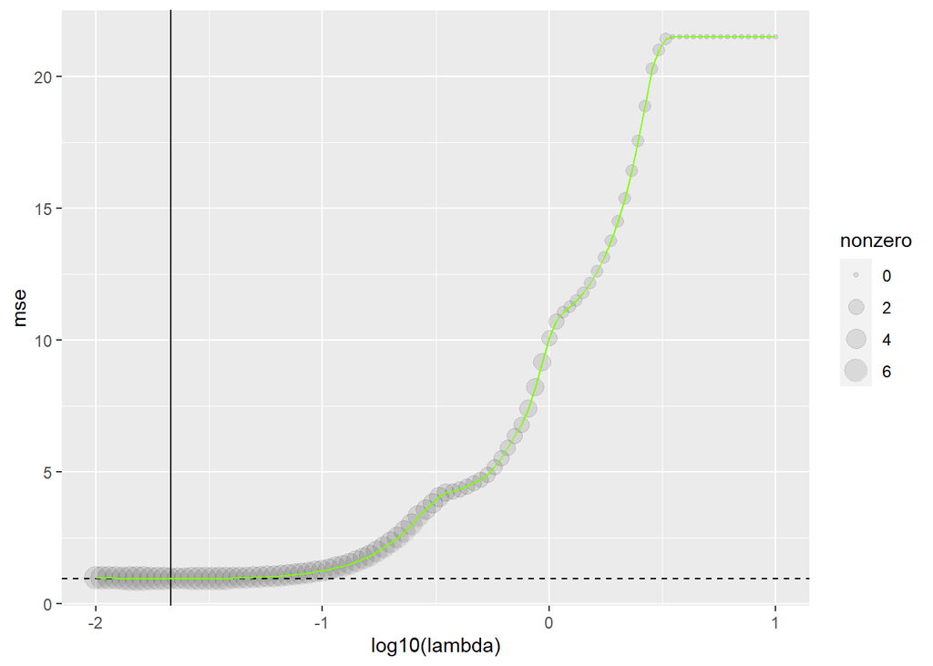

```r
library(glmnet)
grid <- 10^seq(1,-2, length = 100)
dat2 <- as.matrix(dat %>% dplyr::select(-y))
lasso <- cv.glmnet(dat2, y, alpha = 1, lambda = grid, nfolds = 10)

tibble(lambda = lasso$lambda, mse = lasso$cvm, nonzero = lasso$nzero) %>%
  ggplot(aes(x = log10(lambda), y = mse)) +
  geom_point(alpha = .1, aes(size = nonzero)) +
  geom_hline( yintercept = min(lasso$cvm), linetype = "dashed")+
  geom_vline(xintercept = log10(lasso$lambda[which.min(lasso$cvm)]))+
  geom_line(col = "chartreuse")
```

Refit on full data, extract coefs. The best model gets tthe $x^1$ and $x^3$ coefficients right, but $x^2$ is about half the true value, and several superfluous variables are added.

```r
best_lasso <- glmnet(dat2, y, alpha = 1)
predict(best_lasso, s = lasso$lambda.min, type = "coefficients" )
```

```
## 11 x 1 sparse Matrix of class "dgCMatrix"
##                         1
## (Intercept)  3.150517e+00
## x^1          6.887029e+00
## x^2          2.066290e-01
## x^3         -2.959959e+00
## x^4          .
## x^5          .
## x^6          6.046794e-03
## x^7          .
## x^8          3.517365e-04
## x^9          .
## x^10         4.341805e-08
```

```r
y <-  3 + 2*dat$`x^7` +rnorm(100)
dat$y = y
lasso2 <- cv.glmnet(dat2, y, alpha = 1, lambda = grid)
best2 <- regsubsets(y ~., dat, nvmax = 10 )

predict(lasso2, s = lasso2$lambda.min, type = "coefficients")
```

```
## 11 x 1 sparse Matrix of class "dgCMatrix"
##                        1
## (Intercept) 2.9736368246
## x^1         0.0839768946
## x^2         0.0710861165
## x^3         .
## x^4         .
## x^5         0.0102758645
## x^6         .
## x^7         1.9933912036
## x^8         .
## x^9         0.0005975478
## x^10        .
```

```r
summary(best2)$rsq
```

```
##  [1] 0.9999483 0.9999488 0.9999491 0.9999492 0.9999494 0.9999497 0.9999500
##  [8] 0.9999501 0.9999501 0.9999502
```

```r
map2(1:10, list(best2), ~coef(.y, .x))
```

```
## [[1]]
## (Intercept)       `x^7`
##    3.036093    1.999771
##
## [[2]]
## (Intercept)       `x^2`       `x^7`
##  2.97551120  0.07696038  1.99934449
##
## [[3]]
## (Intercept)       `x^1`       `x^2`       `x^7`
##  2.96557391  0.09602936  0.08050347  1.99854101
##
## [[4]]
## (Intercept)       `x^1`       `x^2`       `x^4`       `x^7`
##  2.94361670  0.08773990  0.14778934 -0.01683924  1.99882779
##
## [[5]]
## (Intercept)       `x^4`       `x^6`       `x^7`       `x^8`      `x^10`
##  2.92110868  0.69063511 -0.52389188  1.99960390  0.12843896 -0.01007251
##
## [[6]]
##  (Intercept)        `x^1`        `x^4`        `x^6`        `x^7`        `x^8`
##  2.920318552  0.086465216  0.634454464 -0.475933484  1.998588137  0.115127812
##       `x^10`
## -0.008874182
##
## [[7]]
## (Intercept)       `x^3`       `x^4`       `x^5`       `x^6`       `x^7`
##  2.93524761  0.66351395  0.34549903 -0.65871525 -0.18012513  2.20448125
##       `x^8`       `x^9`
##  0.02328117 -0.02008561
##
## [[8]]
## (Intercept)       `x^1`       `x^3`       `x^4`       `x^5`       `x^6`
##  2.93556597 -0.23810879  1.22557881  0.36473569 -1.03491894 -0.19348926
##       `x^7`       `x^8`       `x^9`
##  2.29800910  0.02529388 -0.02782847
##
## [[9]]
## (Intercept)       `x^2`       `x^3`       `x^4`       `x^5`       `x^6`
##  2.99343457 -0.58369089  0.56323189  1.37778144 -0.51620370 -0.80398524
##       `x^7`       `x^8`       `x^9`      `x^10`
##  2.14775134  0.17206943 -0.01349332 -0.01212604
##
## [[10]]
##  (Intercept)        `x^1`        `x^2`        `x^3`        `x^4`        `x^5`
##  2.991518537 -0.187294233 -0.516353163  1.048521377  1.210775250 -0.869397127
##        `x^6`        `x^7`        `x^8`        `x^9`       `x^10`
## -0.681286963  2.243046138  0.138307603 -0.022029293 -0.009038735
```

Next we are asked to consider how increasing $p$ will reduce trainign but not necessarily test error.

1. Generate a data set with p=20features,n=1,000 observations, and an associated quantitative response vector generatedaccording to the modelY=Xβ+,whereβhas some elements that are exactly equal to zero.
2. Split your data set into a training set containing 100 observationsand a test set containing 900 observations.

I set up data.

```r
set.seed(1)
betas <- sample(-5:5, 20, replace = TRUE)
betas[sample(1:20,5, replace = FALSE)] <- 0
data <- replicate({
  rnorm(mean = sample(-10:10, size = 1), sd = sample(1:5, size =1), n = 1000)},
  n = 20)

y <- data %*% betas +rnorm(100, mean = 10, sd = 5)

inds <- sample(nrow(data), 100, replace = FALSE)
train <- data[inds,]
test <- data[-inds,]
```

We have to manually compute RMSE, which is irritating. The map here finds the betas and multiplies by appropriate predictors.

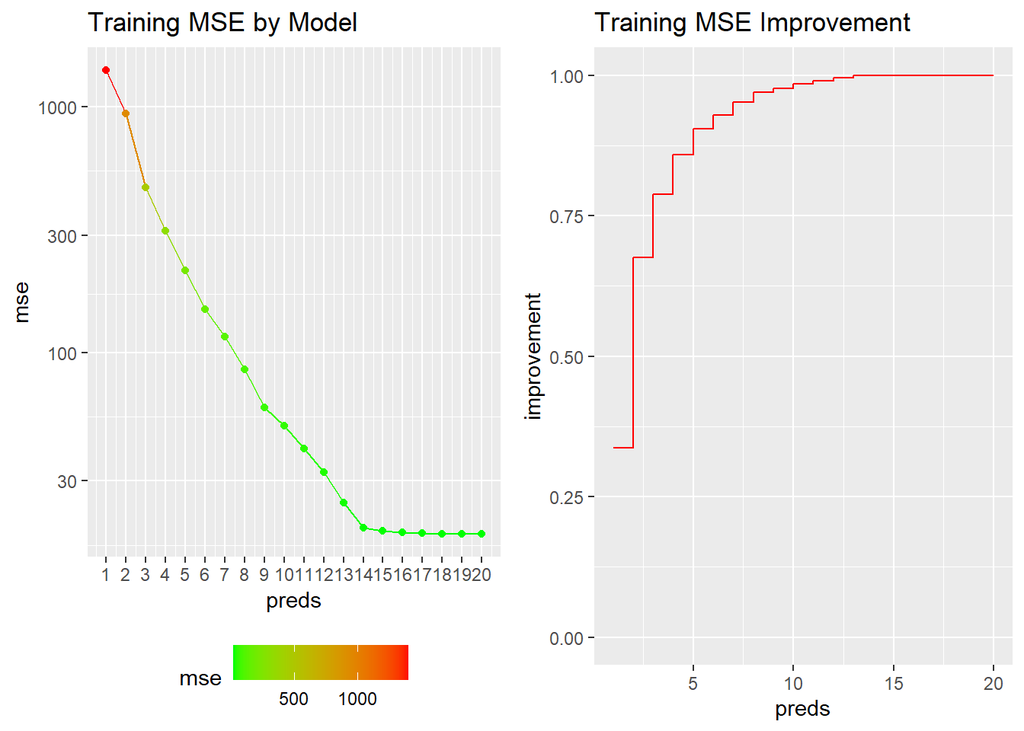

```r
train <- data.frame(train, y = y[inds])
best <- regsubsets(y~., train, nvmax = 20)

errors <- map_dbl(1:20,function(x){
  int <- coef(best, x)[1]
  pred <- as.matrix(train)[,names(coef(best, x))[-1], drop = FALSE]
  betas <- as.matrix(coef(best,x)[-1])
  fit <- pred %*% betas + int
  mse <- mean((y[inds] - fit)^2)
  mse
})

tab <- tibble(preds = 1:20, mse = errors, improvement = cumsum(mse - lead(mse, default = min(mse)))/(max(mse) -min(mse)))
 p1 <- tab %>%  ggplot() +
  geom_line(aes(x = preds, y = mse, col = mse))+
  geom_point(aes(x = preds, y = mse, col = mse)) +
  scale_color_gradient(low = "green", high = "red")+
  scale_x_continuous(breaks = 1:20) +
  scale_y_continuous(trans = "log10") +
   theme(legend.position = "bottom")+
   labs(title = "Training MSE by Model")

p2 <- tab %>% ggplot(aes(x = preds, y = improvement, group =1)) +
  geom_step(col = "red") +
  scale_y_continuous(limits = c(0,1)) +
  ggtitle("Training MSE Improvement")

gridExtra::grid.arrange(p1, p2, ncol =2)
```

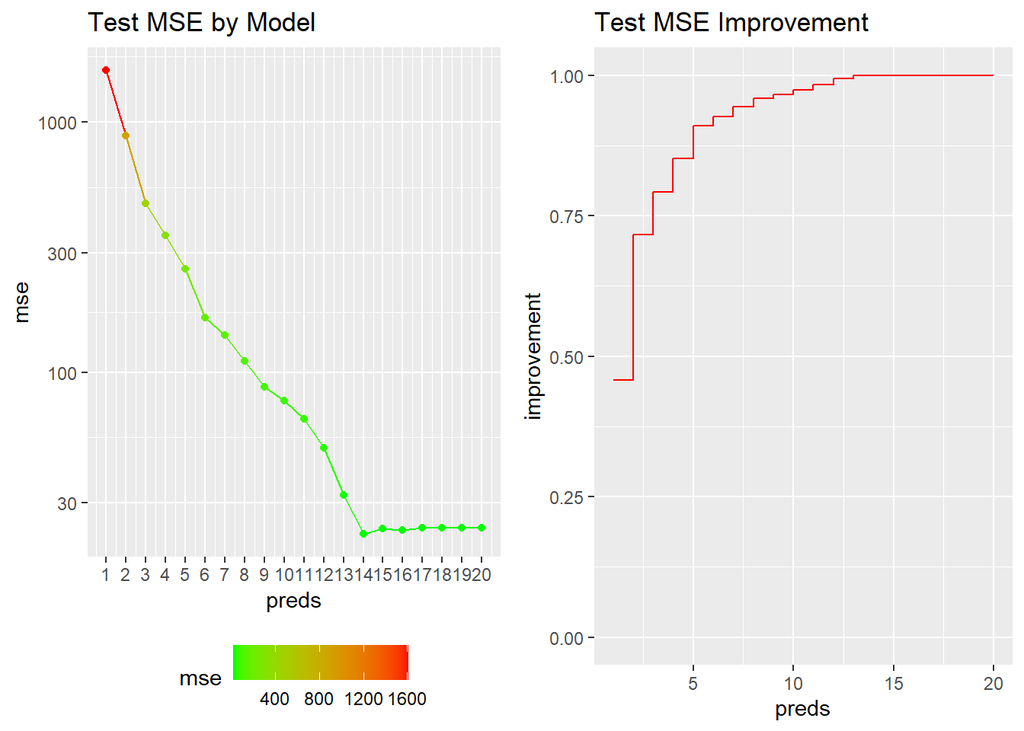

```r
test <- data.frame(test)
errors <- map_dbl(1:20,function(x){
  int <- coef(best, x)[1]
  pred <- as.matrix(test)[,names(coef(best, x))[-1], drop = FALSE]
  betas <- as.matrix(coef(best,x)[-1])
  fit <- pred %*% betas + int
  mse <- mean((y[-inds] - fit)^2)
  mse
})

tab <- tibble(preds = 1:20, mse = errors, improvement = cumsum(mse - lead(mse, default = min(mse)))/(max(mse) -min(mse)))
 p1 <- tab %>%  ggplot() +
  geom_line(aes(x = preds, y = mse, col = mse))+
  geom_point(aes(x = preds, y = mse, col = mse)) +
  scale_color_gradient(low = "green", high = "red")+
  scale_x_continuous(breaks = 1:20) +
  scale_y_continuous(trans = "log10") +
   theme(legend.position = "bottom")+
   labs(title = "Test MSE by Model")

p2 <- tab %>% ggplot(aes(x = preds, y = improvement, group =1)) +
  geom_step(col = "red") +
  scale_y_continuous(limits = c(0,1)) +
  ggtitle("Test MSE Improvement")

gridExtra::grid.arrange(p1, p2, ncol =2)
```

```r
which.min(errors)
```

```
## [1] 14
```

```r
comparison <- tibble(Term =c("(Intercept)", paste0("X", 1:20)), True = c(3, betas)) %>% left_join(enframe(coef(best, 14)), by = c("Term"="name")) %>%
  mutate(Difference = True - value)
```

We are now asked to plot the sqaure root of the sqaured errors of the beta estimates for each model with $j$ predictors - the distance of the variances vector

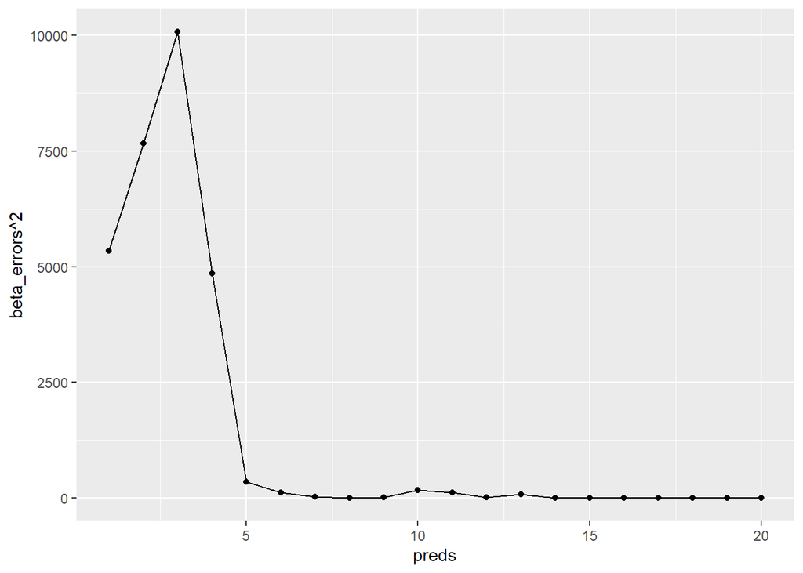

```r
stem <- comparison %>% dplyr::select(., Term, True)
beta_errors <- map_dbl(1:20, function(j){

  diffs <- inner_join(stem, enframe(coef(best, j)),
             by = c("Term"="name")) %>%
    dplyr::select(-Term) %>%
    reduce(`-`)

    sqrt(sum(diffs^2))
})

tibble(preds =1:20, beta_errors) %>% ggplot(aes(x = preds, y = beta_errors^2)) +
  geom_point()+
  geom_line()
```

```r
map(1:20, ~coef(best, .x)[-1]) %>%
  map(names) %>%
  reduce(~c(.x, .y)) %>%
  table() %>%
  sort(decreasing = TRUE)
```

```
## .
##  X4  X7 X16 X10 X11  X8 X20  X6  X3  X1 X17 X13 X19 X12 X14  X5 X15  X2  X9 X18
##  20  19  18  17  16  15  14  13  12  11  10   9   8   7   6   5   4   3   2   1
```

```r
which(betas ==0)
```

```
## [1]  2  5  9 14 15 18
```

# 11.

The last problem asks us to predict per capita crime in Boston. We’d expect home values to be negatively correlated with crime and variables like nitrous oxide and lower-status population to be postively correlated. Suprisingly, tax rate and highway proximity have the strongest correlations.

Black is actually 1000 times the sqaured differnce of proportion black and .063 - presumably the mean

```r
library(MASS)
```

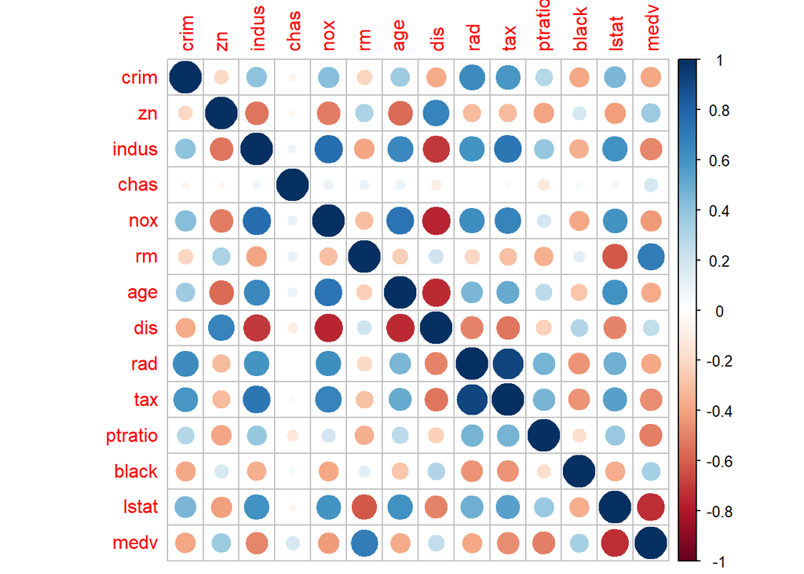

```r
library(corrplot)
inds <- sample(nrow(Boston), nrow(Boston) /2, replace = FALSE)
boston = Boston

cor(Boston) %>% corrplot()
```

```r
split(Boston, Boston$chas) %>%
  map(cor)
```

```
## $`0`
##               crim         zn      indus chas        nox         rm        age
## crim     1.0000000 -0.2036662  0.4124752   NA  0.4382548 -0.2267831  0.3608220
## zn      -0.2036662  1.0000000 -0.5303825   NA -0.5230348  0.3154984 -0.5588438
## indus    0.4124752 -0.5303825  1.0000000   NA  0.7604040 -0.4180360  0.6404333
## chas            NA         NA         NA    1         NA         NA         NA
## nox      0.4382548 -0.5230348  0.7604040   NA  1.0000000 -0.3169924  0.7456314
## rm      -0.2267831  0.3154984 -0.4180360   NA -0.3169924  1.0000000 -0.2491189
## age      0.3608220 -0.5588438  0.6404333   NA  0.7456314 -0.2491189  1.0000000
## dis     -0.3854652  0.6651672 -0.7017997   NA -0.7775872  0.2200129 -0.7456733
## rad      0.6312254 -0.3119962  0.6032034   NA  0.6285504 -0.2334648  0.4617180
## tax      0.5855058 -0.3119347  0.7249974   NA  0.6750295 -0.3173613  0.5108836
## ptratio  0.2863467 -0.4084379  0.4150417   NA  0.2222628 -0.3702554  0.2833619
## black   -0.3865874  0.1790804 -0.3627512   NA -0.3873956  0.1278444 -0.2844417
## lstat    0.4697254 -0.4170865  0.6378243   NA  0.6311820 -0.6020563  0.6219678
## medv    -0.4144305  0.3779124 -0.5386098   NA -0.4634395  0.7008613 -0.4173670
##                dis        rad        tax    ptratio      black      lstat
## crim    -0.3854652  0.6312254  0.5855058  0.2863467 -0.3865874  0.4697254
## zn       0.6651672 -0.3119962 -0.3119347 -0.4084379  0.1790804 -0.4170865
## indus   -0.7017997  0.6032034  0.7249974  0.4150417 -0.3627512  0.6378243
## chas            NA         NA         NA         NA         NA         NA
## nox     -0.7775872  0.6285504  0.6750295  0.2222628 -0.3873956  0.6311820
## rm       0.2200129 -0.2334648 -0.3173613 -0.3702554  0.1278444 -0.6020563
## age     -0.7456733  0.4617180  0.5108836  0.2833619 -0.2844417  0.6219678
## dis      1.0000000 -0.4974634 -0.5351554 -0.2540609  0.2972049 -0.5226478
## rad     -0.4974634  1.0000000  0.9083857  0.4512274 -0.4638759  0.5270406
## tax     -0.5351554  0.9083857  1.0000000  0.4548560 -0.4550336  0.5839306
## ptratio -0.2540609  0.4512274  0.4548560  1.0000000 -0.1907772  0.3885990
## black    0.2972049 -0.4638759 -0.4550336 -0.1907772  1.0000000 -0.3785325
## lstat   -0.5226478  0.5270406  0.5839306  0.3885990 -0.3785325  1.0000000
## medv     0.2882451 -0.4330612 -0.5225460 -0.5406546  0.3437369 -0.7427813
##               medv
## crim    -0.4144305
## zn       0.3779124
## indus   -0.5386098
## chas            NA
## nox     -0.4634395
## rm       0.7008613
## age     -0.4173670
## dis      0.2882451
```

[output cut: 38 more lines]

```
##                black       lstat        medv
## crim    -0.207696573 -0.01836638  0.14803140
## zn       0.154006456 -0.40627191  0.37165430
## indus   -0.347235029  0.12024220 -0.12854266
## chas              NA          NA          NA
## nox     -0.495887150  0.25608905 -0.36148582
## rm       0.096857736 -0.75960200  0.62953630
## age     -0.125675991  0.39447305 -0.22188721
## dis      0.338328724 -0.12656845  0.09380015
## rad     -0.004579998 -0.10885793  0.10390593
## tax     -0.152718855 -0.07384452  0.06574797
## ptratio  0.250584058  0.09738291 -0.06398748
## black    1.000000000 -0.04122474  0.20869460
## lstat   -0.041224744  1.00000000 -0.76271125
## medv     0.208694600 -0.76271125  1.00000000
```

```r
map(Boston, sd)
```

```
## $crim
## [1] 8.601545
##
## $zn
## [1] 23.32245
##
## $indus
## [1] 6.860353
##
## $chas
## [1] 0.253994
##
## $nox
## [1] 0.1158777
##
## $rm
## [1] 0.7026171
##
## $age
## [1] 28.14886
##
## $dis
## [1] 2.10571
##
## $rad
## [1] 8.707259
##
## $tax
## [1] 168.5371
##
## $ptratio
## [1] 2.164946
##
## $black
## [1] 91.29486
##
## $lstat
## [1] 7.141062
##
## $medv
## [1] 9.197104
```

```r
glimpse(boston)
```

```
## Rows: 506
## Columns: 14
## $ crim    <dbl> 0.00632, 0.02731, 0.02729, 0.03237, 0.06905, 0.02985, 0.088...
## $ zn      <dbl> 18.0, 0.0, 0.0, 0.0, 0.0, 0.0, 12.5, 12.5, 12.5, 12.5, 12.5...
## $ indus   <dbl> 2.31, 7.07, 7.07, 2.18, 2.18, 2.18, 7.87, 7.87, 7.87, 7.87,...
## $ chas    <int> 0, 0, 0, 0, 0, 0, 0, 0, 0, 0, 0, 0, 0, 0, 0, 0, 0, 0, 0, 0,...
## $ nox     <dbl> 0.538, 0.469, 0.469, 0.458, 0.458, 0.458, 0.524, 0.524, 0.5...
## $ rm      <dbl> 6.575, 6.421, 7.185, 6.998, 7.147, 6.430, 6.012, 6.172, 5.6...
## $ age     <dbl> 65.2, 78.9, 61.1, 45.8, 54.2, 58.7, 66.6, 96.1, 100.0, 85.9...
## $ dis     <dbl> 4.0900, 4.9671, 4.9671, 6.0622, 6.0622, 6.0622, 5.5605, 5.9...
## $ rad     <int> 1, 2, 2, 3, 3, 3, 5, 5, 5, 5, 5, 5, 5, 4, 4, 4, 4, 4, 4, 4,...
## $ tax     <dbl> 296, 242, 242, 222, 222, 222, 311, 311, 311, 311, 311, 311,...
## $ ptratio <dbl> 15.3, 17.8, 17.8, 18.7, 18.7, 18.7, 15.2, 15.2, 15.2, 15.2,...
## $ black   <dbl> 396.90, 396.90, 392.83, 394.63, 396.90, 394.12, 395.60, 396...
## $ lstat   <dbl> 4.98, 9.14, 4.03, 2.94, 5.33, 5.21, 12.43, 19.15, 29.93, 17...
## $ medv    <dbl> 24.0, 21.6, 34.7, 33.4, 36.2, 28.7, 22.9, 27.1, 16.5, 18.9,...
```

Crime has an extreme right skew. Log-transforming reveals a bimodal distribution. All the high-crime rows have the same proportion of non-retail business acreage and no land zoned for lots over 25000 square feet. Many have 100+-year-old housing stock. They also seem to correspond to the heavily left-skewed black distribution.

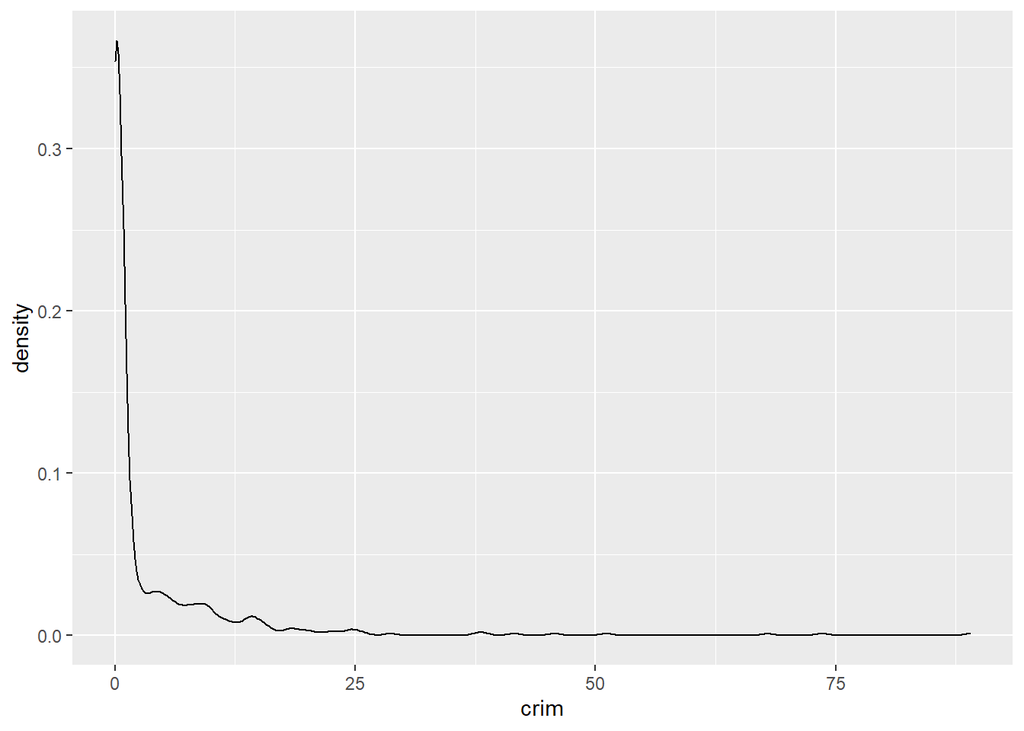

```r
boston %>% ggplot(aes(crim))+
  geom_density()
```

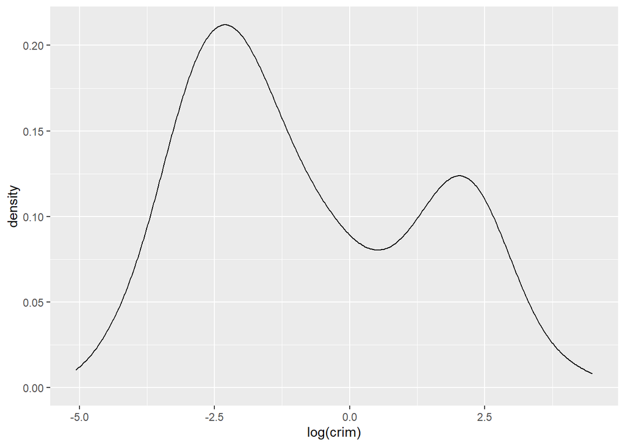

```r
boston %>% ggplot(aes(log(crim)))+
  geom_density()
```

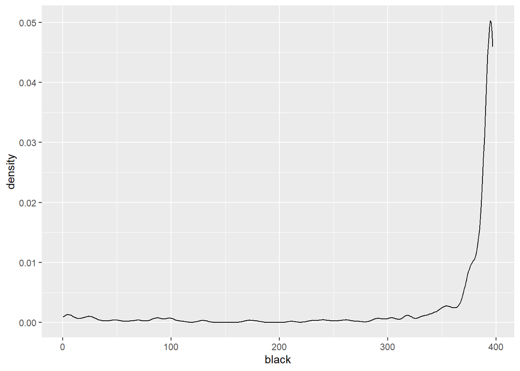

```r
boston %>% ggplot(aes(black))+
  geom_density()
```

```r
boston %>% slice_max(crim, prop=.1)
```

```
##       crim zn indus chas   nox    rm   age    dis rad tax ptratio  black lstat
## 1  88.9762  0  18.1    0 0.671 6.968  91.9 1.4165  24 666    20.2 396.90 17.21
## 2  73.5341  0  18.1    0 0.679 5.957 100.0 1.8026  24 666    20.2  16.45 20.62
## 3  67.9208  0  18.1    0 0.693 5.683 100.0 1.4254  24 666    20.2 384.97 22.98
## 4  51.1358  0  18.1    0 0.597 5.757 100.0 1.4130  24 666    20.2   2.60 10.11
## 5  45.7461  0  18.1    0 0.693 4.519 100.0 1.6582  24 666    20.2  88.27 36.98
## 6  41.5292  0  18.1    0 0.693 5.531  85.4 1.6074  24 666    20.2 329.46 27.38
## 7  38.3518  0  18.1    0 0.693 5.453 100.0 1.4896  24 666    20.2 396.90 30.59
## 8  37.6619  0  18.1    0 0.679 6.202  78.7 1.8629  24 666    20.2  18.82 14.52
## 9  28.6558  0  18.1    0 0.597 5.155 100.0 1.5894  24 666    20.2 210.97 20.08
## 10 25.9406  0  18.1    0 0.679 5.304  89.1 1.6475  24 666    20.2 127.36 26.64
## 11 25.0461  0  18.1    0 0.693 5.987 100.0 1.5888  24 666    20.2 396.90 26.77
## 12 24.8017  0  18.1    0 0.693 5.349  96.0 1.7028  24 666    20.2 396.90 19.77
## 13 24.3938  0  18.1    0 0.700 4.652 100.0 1.4672  24 666    20.2 396.90 28.28
## 14 23.6482  0  18.1    0 0.671 6.380  96.2 1.3861  24 666    20.2 396.90 23.69
```

[output cut: 87 more lines]

```r
mod_sub <- regsubsets(crim~., boston %>% scale %>% as.data.frame(), nvmax = ncol(Boston) - 1)

regsubset_mse <- function(mod, dat, y){
  #browser()
  out <- map_dbl(seq(1, mod$np-1), function(x){
    int <- coef(mod, x)[1]
    pred <- as.matrix(dat)[,names(coef(mod, x))[-1], drop = FALSE]
    betas <- as.matrix(coef(mod,x)[-1])
    fit <- pred %*% betas + int
    mse <- mean((y - fit)^2)
    mse
  })
out
}
regsubset_mse(mod_sub, scale(boston)[inds,], scale(boston$crim)[inds])
```

```
##  [1] 0.8392974 0.8138405 0.7887598 0.7925623 0.7728530 0.7632598 0.7595366
##  [8] 0.7602164 0.7585670 0.7578807 0.7577800 0.7584870 0.7583626
```

```r
coef(mod_sub, 6)
```

```
##   (Intercept)            zn           nox           dis           rad
##  3.805550e-17  1.463169e-01 -1.244622e-01 -2.430460e-01  5.059815e-01
##         black          medv
## -9.245197e-02 -2.095600e-01
```

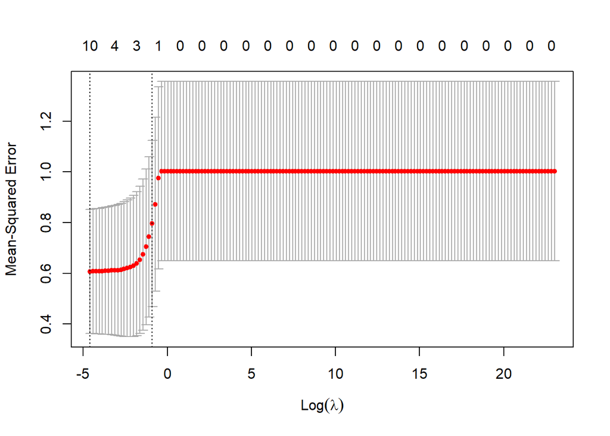

```r
X <- model.matrix(crim ~., boston)[,-1]
Y <- boston$crim
inds <- sample(seq(1, nrow(boston)), nrow(boston)/2, replace = FALSE)
grid <- 10^seq(10, -2, length.out = 150)
lasso_mod <- cv.glmnet(x = X[inds,] %>% scale, y = Y[inds] %>% scale, alpha =1, lambda = grid, nfolds = 10 )

plot(lasso_mod)
```

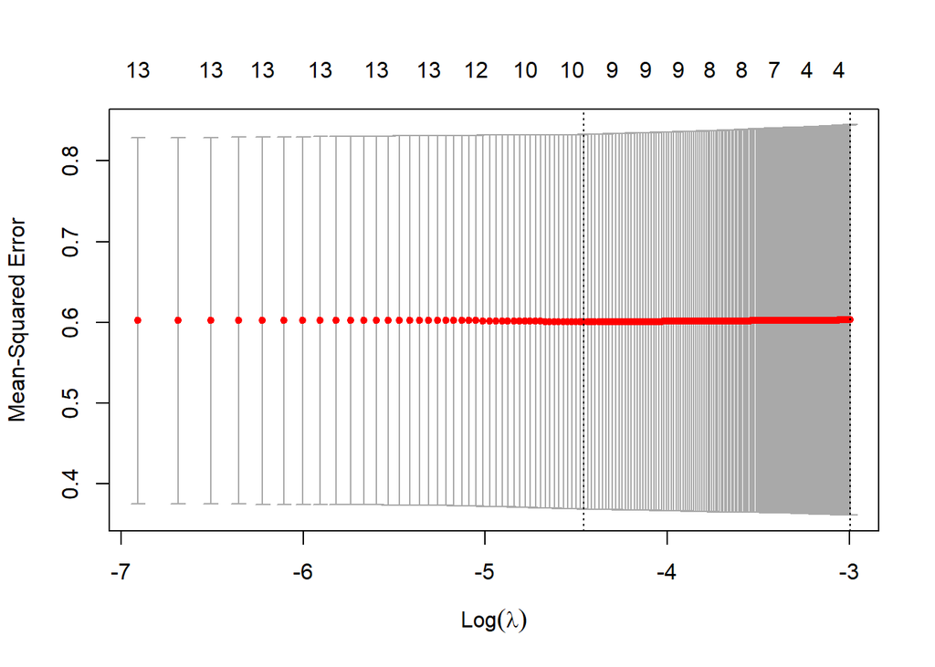

```r
grid <- seq(.001, .05, length.out = 200)
lasso_mod <- cv.glmnet(x = X[inds,] %>% scale, y = Y[inds] %>% scale, alpha =1, lambda = grid, nfolds = 10 )
plot(lasso_mod)
```

Finally, let’s try principal components. Train RMSE is terrible, even if we add components, suggesting sparse data.

```r
mod_pcr <- pcr(crim~., data = boston[inds,], scale = TRUE, validation = "CV", ncomp =3)
summary(mod_pcr)
```

```
## Data:    X dimension: 253 13
##  Y dimension: 253 1
## Fit method: svdpc
## Number of components considered: 3
##
## VALIDATION: RMSEP
## Cross-validated using 10 random segments.
##        (Intercept)  1 comps  2 comps  3 comps
## CV           8.592    7.170    7.125    6.775
## adjCV        8.592    7.164    7.120    6.766
##
## TRAINING: % variance explained
##       1 comps  2 comps  3 comps
## X       47.55    59.65    69.42
## crim    31.75    32.82    39.20
```

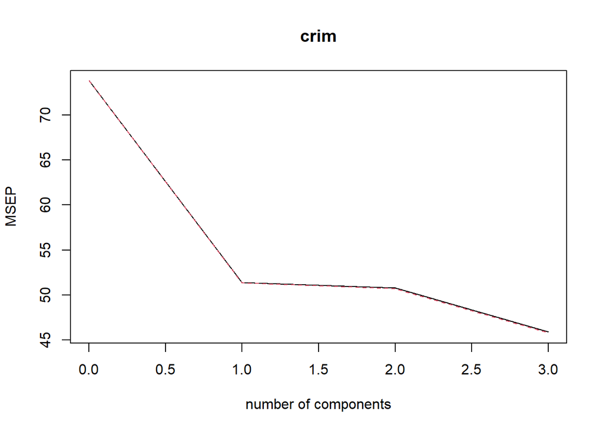

```r
validationplot(mod_pcr, val.type = "MSEP")
```

```r
mean((mod_pcr$fitted.values -scale(Y)[inds])^2)
```

```
## [1] 32.86128
```

```r
mean((predict(lasso_mod, s = lasso_mod$lambda.min, newx = scale(X)[-inds,]) -scale(Y)[-inds])^2)
```

```
## [1] 0.5910678
```

```r
regsubset_mse(mod_sub, scale(boston)[-inds,], scale(Y)[-inds])
```

```
##  [1] 0.6104575 0.5874391 0.5910920 0.5669184 0.5727884 0.5636085 0.5574259
##  [8] 0.5569185 0.5552133 0.5522184 0.5518661 0.5516153 0.5516493
```